# R Notebook

### Learning Phase Score

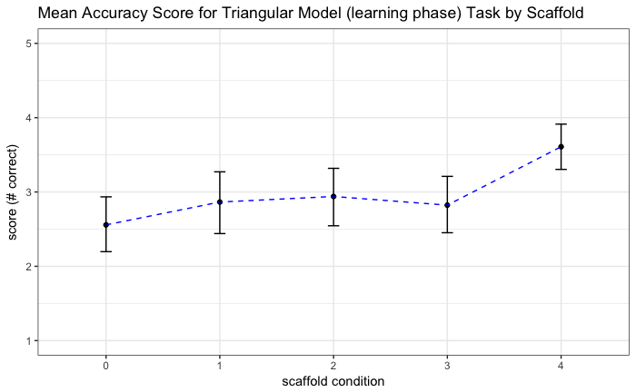

### Learning Phase Time

> Did students spend more time on the learning phase when they had the scaffolds?

Students spend significantly more time on the learning phase questions with the text scaffold than the image scaffolds

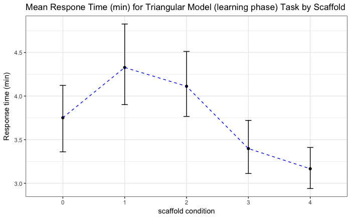

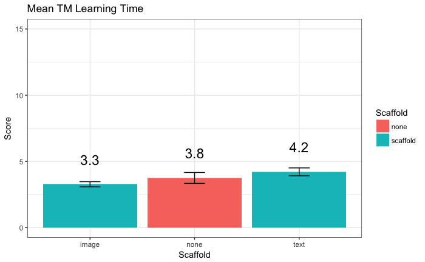

Were there significant differences in learning phase time?

```
 Descriptive statistics by group
group: image
   vars   n     mean      sd median  trimmed      mad   min    max  range skew kurtosis      se
X1    1 131 196565.7 67381.5 187092 188934.6 61351.47 88798 520001 431203 1.45     3.61 5887.15
------------------------------------------------------------------------------------------------------------------
group: text
   vars   n     mean       sd median  trimmed      mad   min    max  range skew kurtosis      se
X1    1 125 252856.6 100189.5 233817 242176.8 75418.38 94052 667514 573462 1.55     3.78 8961.22

    Welch Two Sample t-test

data:  ts_t by scaffTYPE
t = -5.25, df = 215.79, p-value = 3.633e-07
alternative hypothesis: true difference in means is not equal to 0
95 percent confidence interval:
 -77424.18 -35157.55
sample estimates:
mean in group image  mean in group text
           196565.7            252856.6


Cohen's d

d estimate: 0.65641 (medium)
95 percent confidence interval:
      inf       sup
0.4036334 0.9091866

Call:
aov(formula = ts_t ~ condition, data = df_subjects)

Residuals:
    Min      1Q  Median      3Q     Max
-178411  -58642  -11701   38752  407830

Coefficients:
            Estimate Std. Error t value Pr(>|t|)
(Intercept)   225143      11181  20.136   <2e-16 ***
condition1     34541      15946   2.166   0.0311 *
condition2     21611      15510   1.393   0.1645
condition3    -21252      15749  -1.349   0.1782
condition4    -35159      15348  -2.291   0.0226 *
---
Signif. codes:  0 ‘***’ 0.001 ‘**’ 0.01 ‘*’ 0.05 ‘.’ 0.1 ‘ ’ 1

Residual standard error: 87330 on 312 degrees of freedom
Multiple R-squared:  0.08261,   Adjusted R-squared:  0.07085
F-statistic: 7.024 on 4 and 312 DF,  p-value: 2e-05
```

### Compare Scaffolds to Control in TM SCORE

> Are scaffolds more effective than no scaffolds?

From the means, it appears that across all scaffold groups, scores were higher for scaffolds than the no-scaffold control. Students performed significantly better when they had access to a scaffold (M = 9.2, SD = 4.32) than when the did not (M = 6.9, SD = 4.51), t(88) = -3.64, p < .001, d = 0.53, a significant medium effect.

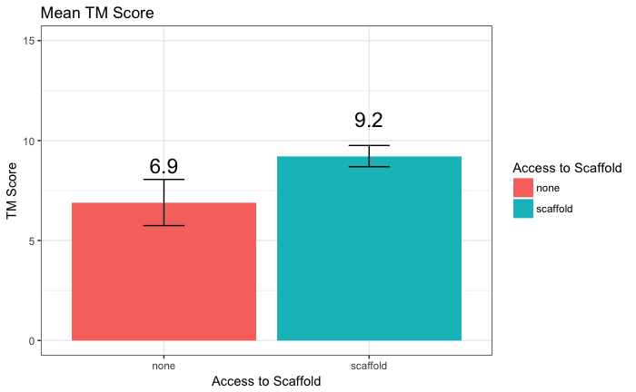

> Is this difference significant?

Students performed significantly better when they had access to a scaffold (M = 9.2, SD = 4.32) than when the did not (M = 6.9, SD = 4.51), t(88) = -3.64, p < .001, d = 0.53, a significant medium effect.

```
 Descriptive statistics by group
group: none
   vars  n mean   sd median trimmed  mad min max range skew kurtosis   se
X1    1 61  6.9 4.51      6    6.86 5.93   0  14    14 0.07    -1.47 0.58
------------------------------------------------------------------------------------------------------------------
group: scaffold
   vars   n mean   sd median trimmed  mad min max range  skew kurtosis   se
X1    1 256 9.22 4.32     10     9.6 4.45   0  15    15 -0.75    -0.67 0.27

    Welch Two Sample t-test

data:  triangular_score by scaffolded
t = -3.6425, df = 88.12, p-value = 0.0004554
alternative hypothesis: true difference in means is not equal to 0
95 percent confidence interval:
 -3.587307 -1.054727
sample estimates:
    mean in group none mean in group scaffold
              6.901639               9.222656


Cohen's d

d estimate: -0.5328912 (medium)
95 percent confidence interval:
       inf        sup
-0.8162938 -0.2494885
```

### Compare Scaffolds to Control in TM TIME

> Are scaffolds more effective than no scaffolds?

No signfificant differences in time

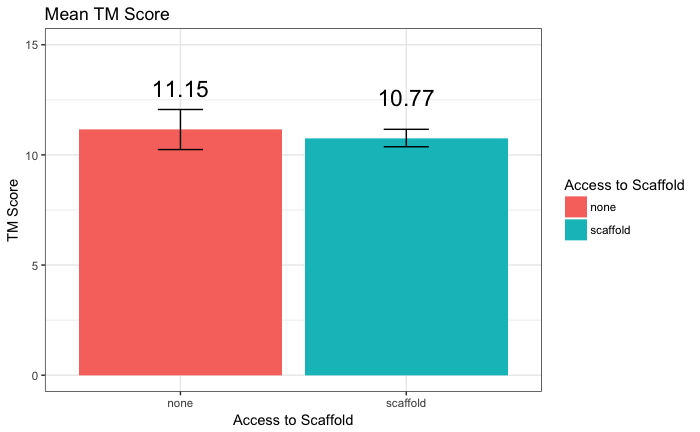

### Compare Scaffolds to Control in DIFF SCORE

> Are scaffolds more effective than no scaffolds?

If we account for the student’s performance on the LM graph by considering the difference in performance between the LM and TM graphs, we see that the difference in performance was significantly smaller when they had access to a scaffold (M = -1.73, SD = 3.88) than when the did not (M = -4.08, SD = 4.51), t(82) = -3.76, p < .001, d = 0.59, a significant medium effect.

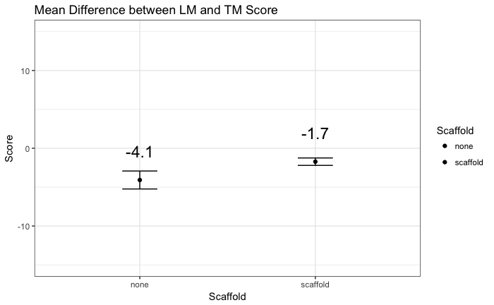

> Is this difference significant?

The difference in performance between the LM and TM graphs was significantly smaller when they had access to a scaffold (M = -1.73, SD = 3.88) than when the did not (M = -4.08, SD = 4.51), t(82) = -3.76, p < .001, d = 0.59, a significant medium effect.

```
 Descriptive statistics by group
group: none
   vars  n  mean   sd median trimmed  mad min max range skew kurtosis   se
X1    1 61 -4.08 4.51     -4   -4.12 5.93 -13   5    18 0.11    -1.04 0.58
------------------------------------------------------------------------------------------------------------------
group: scaffold
   vars   n  mean   sd median trimmed  mad min max range skew kurtosis   se
X1    1 256 -1.73 3.88     -1    -1.4 2.97 -12   5    17 -0.7    -0.16 0.24

    Welch Two Sample t-test

data:  score_diff by scaffolded
t = -3.7612, df = 82.374, p-value = 0.0003153
alternative hypothesis: true difference in means is not equal to 0
95 percent confidence interval:
 -3.601113 -1.109696
sample estimates:
    mean in group none mean in group scaffold
             -4.081967              -1.726562


Cohen's d

d estimate: -0.5881835 (medium)
95 percent confidence interval:
       inf        sup
-0.8722530 -0.3041139
```